# Ionflow: Ionomics data network and enrichment analysis

Wanchang Lin

01-12-2020

This document explains how to performs ionomics data analysis including gene network and enrichment analysis.

## Data preparation

To explore the pipeline, we’ll use the ionomics data set:

```r
ion_data <- read.table("./test-data/iondata.tsv", header = T, sep = "\t")
dim(ion_data)
```

```
#> [1] 9999   16
```

Ten random lines are shown:

```r
sample_n(ion_data, 10)
```

Samples of raw data

| Knockout | Batch_ID | Ca | Cd | Co | Cu | Fe | K | Mg | Mn | Mo | Na | Ni | P | S | Zn |
| --- | --- | --- | --- | --- | --- | --- | --- | --- | --- | --- | --- | --- | --- | --- | --- |
| YOR156C | 25 | 35.43 | 1.09 | 0.14 | 1.69 | 5.32 | 2761.98 | 666.19 | 1.44 | 0.84 | 237.33 | 1.00 | 4644.39 | 490.00 | 16.17 |
| YLR418C | 30 | 43.22 | 0.64 | 0.11 | 1.71 | 7.93 | 1357.12 | 760.45 | 0.91 | 0.91 | 144.41 | 1.59 | 4389.31 | 563.34 | 16.65 |
| YDR349C | 11 | 28.85 | 0.49 | 0.14 | 1.09 | 4.25 | 2339.20 | 299.24 | 1.02 | 0.31 | 128.78 | 0.75 | 1960.78 | 381.50 | 9.38 |
| YEL057C | 13 | 45.48 | 1.09 | 0.16 | 1.41 | 5.34 | 3392.76 | 553.53 | 1.68 | 2.29 | 87.87 | 1.64 | 3995.50 | 656.24 | 16.34 |
| YAL021C | 79 | 38.10 | 1.44 | 0.14 | 1.43 | 4.11 | 3236.74 | 460.36 | 1.03 | 0.70 | 24.55 | 0.57 | 3737.31 | 236.49 | 10.13 |
| YDL227C | 10 | 11.96 | 0.72 | 0.17 | 1.43 | 2.94 | 2230.09 | 366.93 | 1.08 | 0.41 | 120.41 | 0.99 | 2707.44 | 213.46 | 14.10 |
| YDR395W | 12 | 53.36 | 1.19 | 0.24 | 2.85 | 13.02 | 5914.12 | 844.04 | 2.01 | 2.07 | 296.69 | 2.99 | 6020.75 | 1119.65 | 23.92 |
| YDR406W | 12 | 43.50 | 1.07 | 0.19 | 2.27 | 11.21 | 3698.45 | 718.78 | 1.65 | 2.06 | 187.40 | 1.80 | 5353.61 | 577.25 | 19.89 |
| YDL227C | 8 | 38.39 | 0.66 | 0.16 | 1.59 | 10.53 | 2544.82 | 438.03 | 1.27 | 0.57 | 169.91 | 1.23 | 3430.24 | 458.42 | 17.10 |
| YLL020C | 19 | 27.31 | 0.97 | 0.13 | 1.32 | 2.97 | 2409.10 | 511.37 | 0.88 | 1.02 | 154.17 | 0.82 | 3793.87 | 384.08 | 13.12 |

We can see that the first few columns are meta information such as gene ORF and batch id. The rest is the ionomics data.

## Data pre-process

The raw data set is needed to be pre-processed. This involves:

- log transformation
- batch correction
- outlier detection
- standardisation

For batch correction, control line could be used. If so, the values belong to control lines are used to be the basis of batch correlation. This data has a control line: **YDL227C** mutant. The code segment below is to identify it:

```r
max(with(ion_data, table(Knockout)))
```

```
#> [1] 1617
```

```r
which.max(with(ion_data, table(Knockout)))
```

```
#> YDL227C
#>     209
```

Standarisation provides a *custom* method. This allows user to use specific std values such as:

```r
std <- read.table("./test-data/user_std.tsv", header = T, sep = "\t")
std
```

```
#>    Ion     sd
#> 1   Ca 0.1508
#> 2   Cd 0.0573
#> 3   Co 0.0580
#> 4   Cu 0.0735
#> 5   Fe 0.1639
#> 6    K 0.0940
#> 7   Mg 0.0597
#> 8   Mn 0.0771
#> 9   Mo 0.1142
#> 10  Na 0.1075
#> 11  Ni 0.0784
#> 12   P 0.0597
#> 13   S 0.0801
#> 14  Zn 0.0671
```

The pre-process procedure returns not only processed ionomics data but also a symbolic data. This data is based on the inomics data and a threshold(`thres_symb`):

- `0` if ionomics data located between `[-thres_symb, thres_symb]`
- `1` if ionomics data larger than `thres_symb`
- `-1` if ionomics data smaller than `-thres_symb`

Ths symbolic data is important since the network analysis will use it along with ionomics data, and enrichment analysis will be performd only based on it. It also should be noted that the symblic data is sensitive to the choices of the threshold.

Let’s run the pre-process procedure:

```r
pre <- PreProcessing(data = ion_data,
                     var_id = 1, batch_id = 2, data_id = 3,
                     method_norm = "median",
                     control_lines = "YDL227C",
                     control_use = "control",
                     method_outliers = "IQR",
                     thres_outl = 3,
                     stand_method = "std",
                     stdev = NULL,
                     thres_symb = 3)

names(pre)
```

```
#> [1] "stats.raw_data"    "stats.outliers"    "stats.batch_data"
#> [4] "data.long"         "data.gene.logFC"   "data.gene.zscores"
#> [7] "data.gene.symb"    "plot.dot"          "plot.hist"
```

```r
pre$stats.batch_data %>% kable(caption = 'Summary: z-scores', digits = 2) %>%
  kable_styling(full_width = F, font_size = 10)
```

| Ion | Min. | 1st Qu. | Median | Mean | 3rd Qu. | Max. | Variance |
| --- | --- | --- | --- | --- | --- | --- | --- |
| Ca | -4.45 | -0.28 | -0.13 | -0.12 | 0.02 | 2.35 | 0.11 |
| Cd | -1.70 | 0.03 | 0.10 | 0.11 | 0.17 | 0.93 | 0.03 |
| Co | -2.80 | 0.02 | 0.09 | 0.06 | 0.15 | 1.60 | 0.05 |
| Cu | -0.66 | -0.10 | -0.03 | -0.01 | 0.04 | 5.28 | 0.04 |
| Fe | -7.48 | -0.17 | -0.06 | -0.02 | 0.07 | 6.88 | 0.14 |
| K | -2.21 | -0.17 | -0.01 | -0.08 | 0.09 | 1.83 | 0.08 |
| Mg | -1.84 | -0.06 | 0.01 | -0.01 | 0.07 | 1.69 | 0.03 |
| Mn | -4.11 | -0.24 | -0.08 | -0.13 | 0.01 | 1.78 | 0.06 |
| Mo | -2.03 | -0.26 | -0.08 | -0.08 | 0.09 | 4.44 | 0.13 |
| Na | -7.41 | -0.53 | -0.22 | -0.33 | -0.04 | 1.25 | 0.24 |
| Ni | -2.40 | -0.01 | 0.09 | 0.12 | 0.21 | 7.90 | 0.12 |
| P | -1.18 | -0.06 | 0.00 | -0.01 | 0.06 | 1.45 | 0.02 |
| S | -2.38 | -0.03 | 0.05 | 0.06 | 0.16 | 2.38 | 0.04 |
| Zn | -0.46 | -0.08 | -0.03 | -0.01 | 0.03 | 4.60 | 0.02 |

The pre-processed data and its symbolic data are like like:

```r
pre$data.gene.zscores %>% sample_n(10) %>%
  kable(caption = 'Pre-processed data', digits = 2) %>%
  kable_styling(full_width = F, font_size = 10)
```

Pre-processed data

| Line | Ca | Cd | Co | Cu | Fe | K | Mg | Mn | Mo | Na | Ni | P | S | Zn |
| --- | --- | --- | --- | --- | --- | --- | --- | --- | --- | --- | --- | --- | --- | --- |
| YHR143W | -3.70 | 0.39 | 0.61 | 0.13 | -1.88 | 1.08 | 0.33 | 0.22 | -0.44 | -1.30 | 0.87 | 0.46 | -0.12 | -0.53 |
| YOR173W | -0.68 | 0.92 | 0.47 | -0.15 | -1.84 | -1.01 | 0.11 | 0.46 | -0.03 | 1.19 | 0.12 | 0.86 | 1.69 | -0.08 |
| YDR111C | -1.30 | 0.71 | 0.53 | 0.09 | -1.07 | 0.70 | -0.28 | -0.50 | -0.28 | -3.61 | 0.93 | -0.64 | -0.61 | -0.17 |
| YGR159C | -0.19 | -0.09 | -0.14 | -0.15 | -0.06 | 1.74 | -0.79 | -0.18 | 0.28 | -1.85 | -1.45 | -0.48 | -0.45 | 2.08 |
| YBR227C | 0.18 | 1.34 | 1.25 | 0.80 | 0.00 | -0.64 | -0.36 | -3.88 | -1.10 | -2.11 | 7.86 | -0.14 | -0.08 | -0.53 |
| YLL002W | -0.02 | -1.33 | -1.44 | 0.41 | 0.22 | 0.71 | -0.33 | 0.37 | -0.93 | 0.37 | -0.41 | -0.24 | 0.95 | 0.07 |
| YLR281C | -0.60 | 1.84 | 1.53 | 0.20 | -0.56 | 1.21 | 0.12 | -0.58 | -1.28 | -2.09 | 0.54 | 0.77 | 0.94 | -0.02 |
| YGR043C | 0.82 | 2.51 | 1.46 | 0.42 | 0.14 | -0.17 | -0.67 | 2.17 | 1.71 | -9.89 | 5.39 | 0.04 | 0.15 | -0.22 |
| YDR179C | -0.62 | 0.64 | 0.66 | -1.22 | -0.59 | 0.08 | 0.16 | -0.46 | -0.85 | -1.52 | 0.08 | 0.06 | 0.12 | -0.09 |
| YBR264C | -0.14 | 0.24 | 0.22 | -0.90 | -1.22 | 1.38 | 0.58 | 0.01 | -1.26 | -0.48 | 0.12 | 0.49 | 0.74 | 0.08 |

```r
pre$data.gene.symb %>% sample_n(10) %>%
  kable(caption = 'Symbolic data') %>%
  kable_styling(full_width = F, font_size = 10)
```

Symbolic data

| Line | Ca | Cd | Co | Cu | Fe | K | Mg | Mn | Mo | Na | Ni | P | S | Zn |
| --- | --- | --- | --- | --- | --- | --- | --- | --- | --- | --- | --- | --- | --- | --- |
| YHR018C | 0 | 0 | 0 | 0 | 0 | 0 | 0 | 0 | 0 | -1 | 0 | 0 | 0 | 0 |
| YER085C | 0 | 0 | 0 | 0 | 0 | 0 | 0 | 0 | 0 | 0 | 0 | 0 | 0 | 0 |
| YHL036W | 0 | 0 | 0 | 0 | 0 | 0 | 0 | 0 | 0 | -1 | 0 | 0 | 0 | 0 |
| YLR421C | 0 | 0 | 0 | 0 | 0 | 0 | 0 | 0 | 0 | 0 | 0 | 0 | 0 | 0 |
| YLR168C | 0 | 0 | 0 | 0 | 0 | 0 | 0 | 0 | 0 | -1 | 0 | 0 | 0 | 0 |
| YGL231C | 0 | 0 | 0 | 0 | 0 | 0 | 0 | 0 | 0 | 0 | 0 | 0 | 0 | 0 |
| YAL010C | 0 | 0 | 0 | 0 | 0 | 0 | 0 | 0 | -1 | -1 | 0 | 0 | 0 | 0 |
| YOR166C | 0 | 0 | 0 | 0 | 0 | 0 | 0 | 0 | 0 | 0 | 0 | 0 | 0 | 0 |
| YOR115C | 0 | 0 | 0 | 0 | 0 | 0 | 0 | 0 | 0 | 0 | 0 | 0 | 0 | 0 |
| YOR182C | 0 | 0 | 0 | 0 | 0 | 0 | 0 | 0 | 0 | -1 | 0 | 0 | 0 | 0 |

The pre-processed data distribution is:

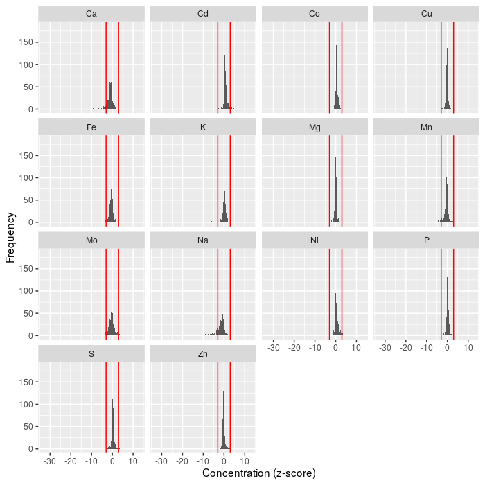

Ionome data distribution plot

```r
pre$plot.hist
```

## Data filter

There are a lot of ways to filter gene. Here we filter gene based on symbolic data:

```r
data <- pre$data.gene.zscores
data_symb <- pre$data.gene.symb
idx <- rowSums(abs(data_symb[, -1])) > 0
dat <- data[idx, ]
dat_symb <- data_symb[idx, ]
dim(dat)
```

```
#> [1] 549  15
```

## Gene network

The gene network is based on the ionomics and symboloc data and uses the similarity measure results to build up the network. The similarity measure method is one of *pearson*, *spearman*, *kendall*, *cosine*, *mahal_cosine* or *hybrid_mahal_cosine*.

First, the Pearson correlation is used to build up the network:

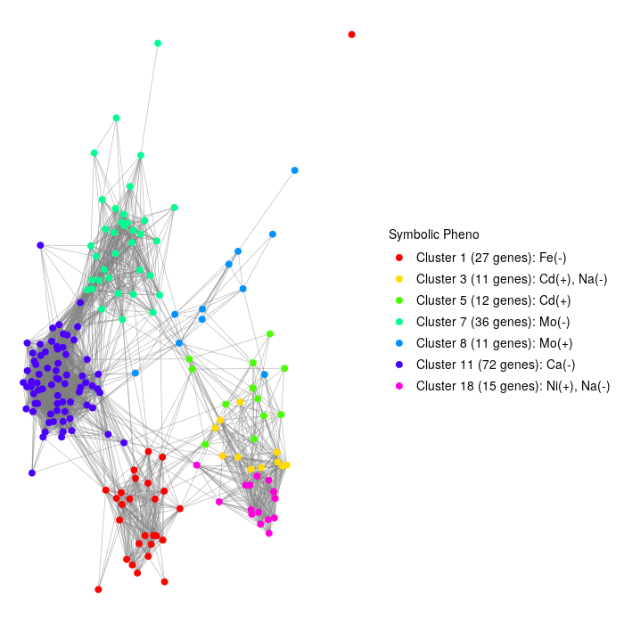

Netwok analysis based on Pearson correlation

```r
net <- GeneNetwork(data = dat,
                   data_symb = dat_symb,
                   min_clust_size = 10,
                   thres_corr = 0.75,
                   method_corr = "pearson")
net$plot.pnet1
```

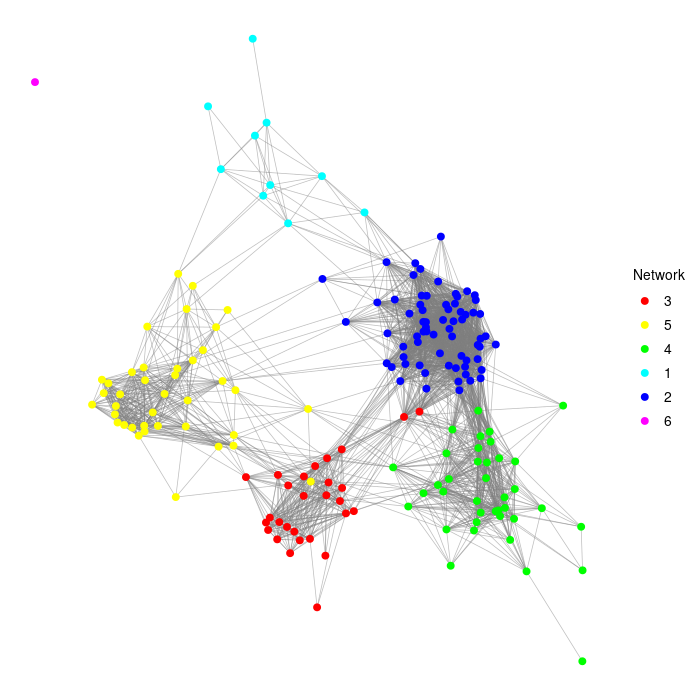

Netwok analysis based on Pearson correlation

```r
net$plot.pnet2
```

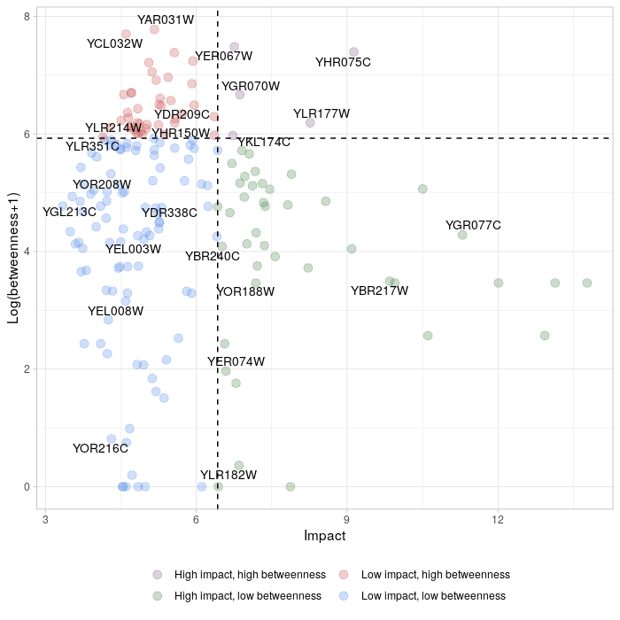

Netwok analysis based on Pearson correlation

```r
net$plot.impact_betweenness
```

For the comparision, we use different similarity methods. Here use *Cosine*:

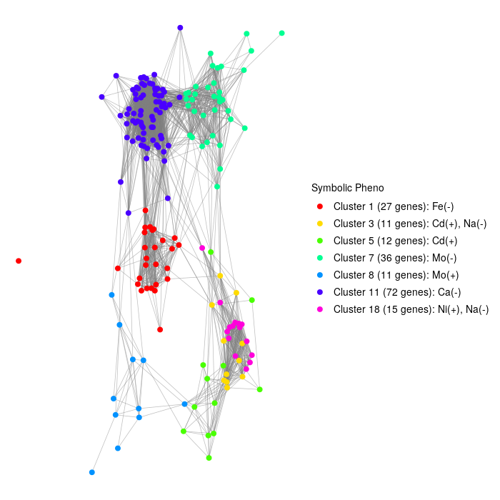

Netwok analysis based on Cosine

```r
net_1 <- GeneNetwork(data = dat,
                     data_symb = dat_symb,
                     min_clust_size = 10,
                     thres_corr = 0.75,
                     method_corr = "cosine")
net_1$plot.pnet1
```

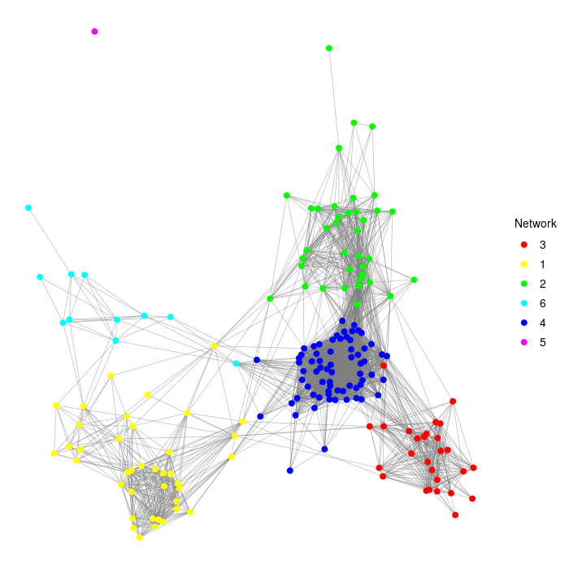

Netwok analysis based on Cosine

```r
net_1$plot.pnet2
```

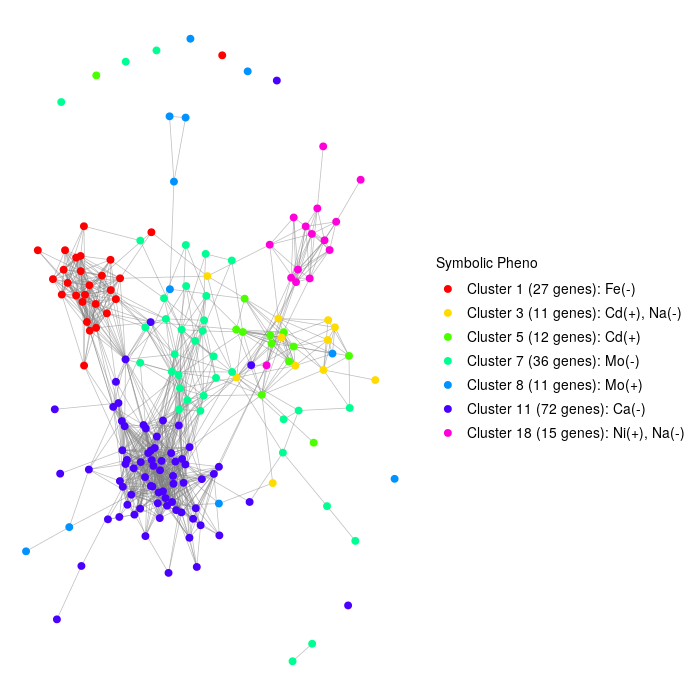

Netwok analysis based on Mahalanobis Cosine

```r
net_2 <- GeneNetwork(data = dat,
                     data_symb = dat_symb,
                     min_clust_size = 10,
                     thres_corr = 0.75,
                     method_corr = "mahal_cosine")
net_2$plot.pnet1
```

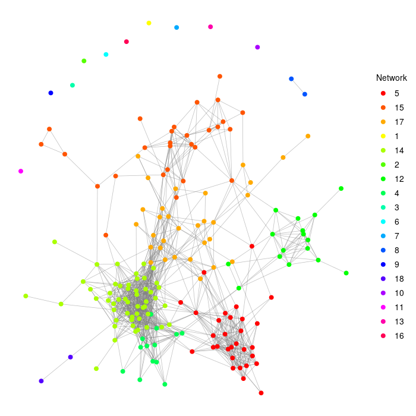

Netwok analysis based on Mahalanobis Cosine

```r
net_2$plot.pnet2
```

Again, we use *Hybrid Mahalanobis Cosine*:

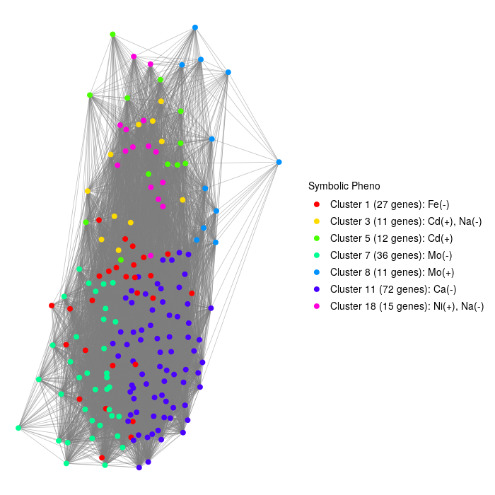

Netwok analysis based on Hybrid Mahalanobis Cosine

```r
net_3 <- GeneNetwork(data = dat,
                     data_symb = dat_symb,
                     min_clust_size = 10,
                     thres_corr = 0.75,
                     method_corr = "hybrid_mahal_cosine")
net_3$plot.pnet1
```

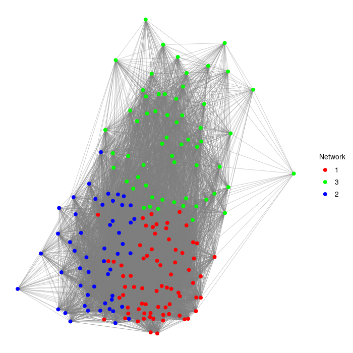

Netwok analysis based on Hybrid Mahalanobis Cosine

```r
net_3$plot.pnet2
```

## Enrichment analysis

The KEGG enrichment analysis:

```r
kegg <- kegg_enrich(data = dat_symb, min_clust_size = 10, pval = 0.05,
                    annot_pkg =  "org.Sc.sgd.db")

#' kegg
kegg %>%
  kable(caption = 'KEGG enrichmenat analysis', digits = 3) %>%
  kable_styling(full_width = F, font_size = 10)
```

KEGG enrichmenat analysis

| Cluster | KEGGID | Pvalue | Count | Size | Term |
| --- | --- | --- | --- | --- | --- |
| Cluster 7 (36 genes) | 03010 | 0.029 | 9 | 16 | Ribosome |
| Cluster 7 (36 genes) | 00330 | 0.031 | 3 | 3 | Arginine and proline metabolism |
| Cluster 18 (15 genes) | 00290 | 0.009 | 2 | 2 | Valine, leucine and isoleucine biosynthesis |
| Cluster 18 (15 genes) | 00520 | 0.009 | 2 | 2 | Amino sugar and nucleotide sugar metabolism |
| Cluster 18 (15 genes) | 00260 | 0.012 | 3 | 6 | Glycine, serine and threonine metabolism |
| Cluster 18 (15 genes) | 00010 | 0.024 | 2 | 3 | Glycolysis / Gluconeogenesis |
| Cluster 18 (15 genes) | 01110 | 0.037 | 5 | 22 | Biosynthesis of secondary metabolites |
| Cluster 3 (11 genes) | 00400 | 0.009 | 2 | 2 | Phenylalanine, tyrosine and tryptophan biosynthesis |
| Cluster 8 (11 genes) | 01100 | 0.006 | 6 | 55 | Metabolic pathways |
| Cluster 8 (11 genes) | 00564 | 0.027 | 2 | 6 | Glycerophospholipid metabolism |

Note that there can be none results for KRGG enrichment analysis. Change arguments such as `thres_clus` as appropriate.

The GO Terms enrichment analysis:

```r
go <- go_enrich(data = dat_symb, min_clust_size = 10, pval = 0.05,
                ont = "BP", annot_pkg =  "org.Sc.sgd.db")
#' go
go %>% sample_n(10) %>%
  kable(caption = 'GO Terms enrichmenat analysis', digits = 3) %>%
  kable_styling(full_width = F, font_size = 10)
```

GO Terms enrichmenat analysis

[output not shown]

## Exploratory analysis

Some analysis are performed in terms of ions, i.e. feature, including PCA and correlation.

```r
expl <- ExploratoryAnalysis(data = dat)
```

[figure not shown]

Exploratory analysis plots with respect to ionome

[figure not shown]

Exploratory analysis plots with respect to ionome

[figure not shown]

Exploratory analysis plots with respect to ionome

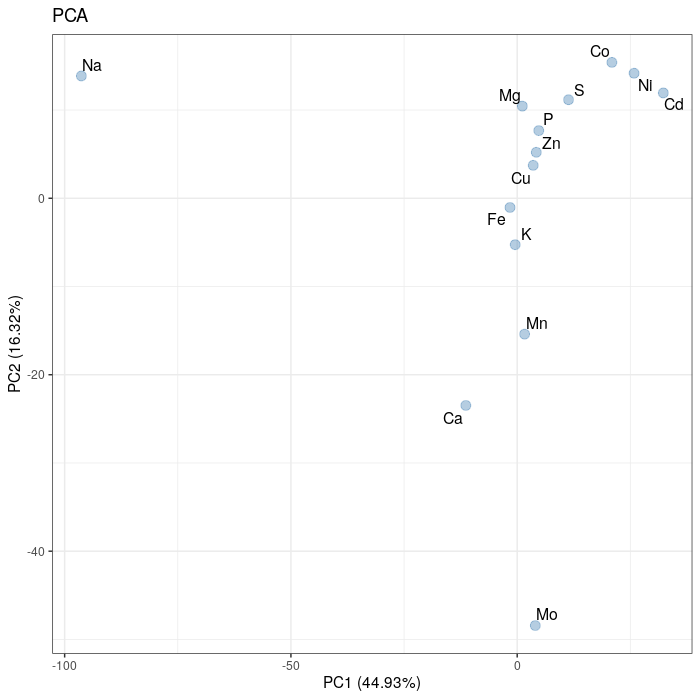

Exploratory analysis plots with respect to ionome

```r
expl$plot.PCA_Individual
```

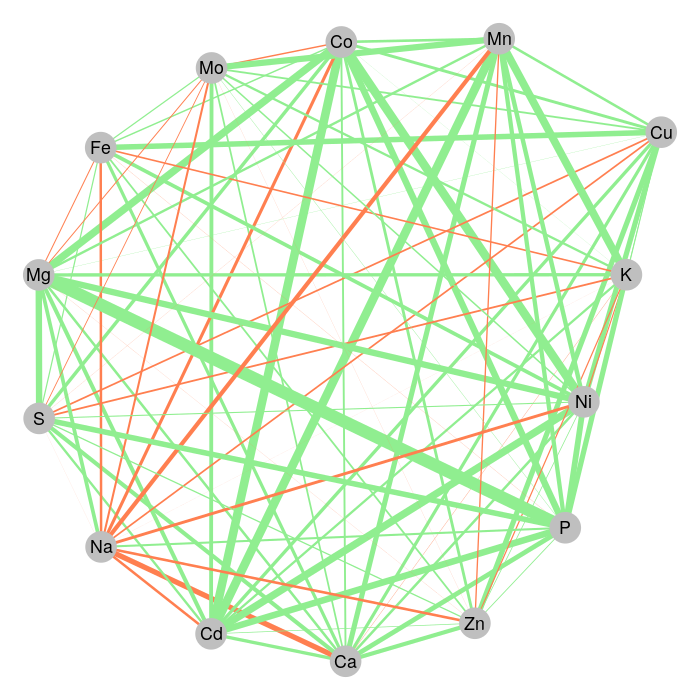

Exploratory analysis plots with respect to ionome

```r
expl$plot.correlation_network
```